# Python Project - (Prosper Loan)

## Preliminary Wrangling

```python
# import all packages
import numpy as np
import pandas as pd
import matplotlib.pyplot as plt
import seaborn as sns
```

```python
df = pd.read_csv('Copy of Prosper Loan.csv')
```

```python
df
```

|  | ListingKey | ListingNumber | ListingCreationDate | CreditGrade | Term | LoanStatus | ClosedDate | BorrowerAPR | BorrowerRate | LenderYield | ... | LP_ServiceFees | LP_CollectionFees | LP_GrossPrincipalLoss | LP_NetPrincipalLoss | LP_NonPrincipalRecoverypayments | PercentFunded | Recommendations | InvestmentFromFriendsCount | InvestmentFromFriendsAmount | Investors |
| --- | --- | --- | --- | --- | --- | --- | --- | --- | --- | --- | --- | --- | --- | --- | --- | --- | --- | --- | --- | --- | --- |
| 0 | 1021339766868145413AB3B | 193129 | 09:29.3 | C | 36 | Completed | 14/08/2009 00:00 | 0.16516 | 0.1580 | 0.1380 | ... | -133.18 | 0.0 | 0.0 | 0.0 | 0.0 | 1.0 | 0 | 0 | 0.0 | 258 |
| 1 | 10273602499503308B223C1 | 1209647 | 28:07.9 | NaN | 36 | Current | NaN | 0.12016 | 0.0920 | 0.0820 | ... | 0.00 | 0.0 | 0.0 | 0.0 | 0.0 | 1.0 | 0 | 0 | 0.0 | 1 |
| 2 | 0EE9337825851032864889A | 81716 | 00:47.1 | HR | 36 | Completed | 17/12/2009 00:00 | 0.28269 | 0.2750 | 0.2400 | ... | -24.20 | 0.0 | 0.0 | 0.0 | 0.0 | 1.0 | 0 | 0 | 0.0 | 41 |
| 3 | 0EF5356002482715299901A | 658116 | 02:35.0 | NaN | 36 | Current | NaN | 0.12528 | 0.0974 | 0.0874 | ... | -108.01 | 0.0 | 0.0 | 0.0 | 0.0 | 1.0 | 0 | 0 | 0.0 | 158 |
| 4 | 0F023589499656230C5E3E2 | 909464 | 38:39.1 | NaN | 36 | Current | NaN | 0.24614 | 0.2085 | 0.1985 | ... | -60.27 | 0.0 | 0.0 | 0.0 | 0.0 | 1.0 | 0 | 0 | 0.0 | 20 |
| ... | ... | ... | ... | ... | ... | ... | ... | ... | ... | ... | ... | ... | ... | ... | ... | ... | ... | ... | ... | ... | ... |
| 113932 | E6D9357655724827169606C | 753087 | 55:02.7 | NaN | 36 | Current | NaN | 0.22354 | 0.1864 | 0.1764 | ... | -75.58 | 0.0 | 0.0 | 0.0 | 0.0 | 1.0 | 0 | 0 | 0.0 | 1 |
| 113933 | E6DB353036033497292EE43 | 537216 | 42:55.3 | NaN | 36 | FinalPaymentInProgress | NaN | 0.13220 | 0.1110 | 0.1010 | ... | -30.05 | 0.0 | 0.0 | 0.0 | 0.0 | 1.0 | 0 | 0 | 0.0 | 22 |
| 113934 | E6E13596170052029692BB1 | 1069178 | 49:12.7 | NaN | 60 | Current | NaN | 0.23984 | 0.2150 | 0.2050 | ... | -16.91 | 0.0 | 0.0 | 0.0 | 0.0 | 1.0 | 0 | 0 | 0.0 | 119 |
| 113935 | E6EB3531504622671970D9E | 539056 | 18:26.6 | NaN | 60 | Completed | 13/08/2013 00:00 | 0.28408 | 0.2605 | 0.2505 | ... | -235.05 | 0.0 | 0.0 | 0.0 | 0.0 | 1.0 | 0 | 0 | 0.0 | 274 |
| 113936 | E6ED3600409833199F711B7 | 1140093 | 27:37.7 | NaN | 36 | Current | NaN | 0.13189 | 0.1039 | 0.0939 | ... | -1.70 | 0.0 | 0.0 | 0.0 | 0.0 | 1.0 | 0 | 0 | 0.0 | 1 |

113937 rows × 81 columns

```python
# Check for missing values in the dataset
df.isnull().sum()
```

```
ListingKey                         0
ListingNumber                      0
ListingCreationDate                0
CreditGrade                    84984
Term                               0
                               ...
PercentFunded                      0
Recommendations                    0
InvestmentFromFriendsCount         0
InvestmentFromFriendsAmount        0
Investors                          0
Length: 81, dtype: int64
```

```python
missing_values = df.isnull().sum()
```

```python
# Drop columns with more than 50% missing values
threshold = len(df) * 0.5
columns_to_drop = missing_values[missing_values > threshold].index
```

```python
columns_to_drop
```

```
Index(['CreditGrade', 'ClosedDate', 'GroupKey', 'TotalProsperLoans',
       'TotalProsperPaymentsBilled', 'OnTimeProsperPayments',
       'ProsperPaymentsLessThanOneMonthLate',
       'ProsperPaymentsOneMonthPlusLate', 'ProsperPrincipalBorrowed',
       'ProsperPrincipalOutstanding', 'ScorexChangeAtTimeOfListing',
       'LoanFirstDefaultedCycleNumber'],
      dtype='object')
```

```python
# Drop the identified columns
df_cleaned = df.drop(columns=columns_to_drop)
```

```python
# Fill missing values for numerical columns with the median
numerical_cols = df_cleaned.select_dtypes(include=[np.number]).columns
for col in numerical_cols:
    df_cleaned.fillna({col:df_cleaned[col].median()}, inplace=True)
```

```python
# Fill missing values for categorical columns with the mode
categorical_cols = df_cleaned.select_dtypes(include=['object']).columns
for col in categorical_cols:
    df_cleaned.fillna({col:df_cleaned[col].mode()}, inplace=True)
```

```python
# Convert date columns to datetime format
for col in df_cleaned.columns:
    if 'Date' in col or 'date' in col:
        df_cleaned[col] = pd.to_datetime(df_cleaned[col], format="%d/%m/%Y", errors='coerce')
```

```python
# Display the cleaned dataset information
df_cleaned.info()
```

```
<class 'pandas.core.frame.DataFrame'>
RangeIndex: 113937 entries, 0 to 113936
Data columns (total 69 columns):
 #   Column                              Non-Null Count   Dtype
---  ------                              --------------   -----
 0   ListingKey                          113937 non-null  object
 1   ListingNumber                       113937 non-null  int64
 2   ListingCreationDate                 0 non-null       datetime64[ns]
 3   Term                                113937 non-null  int64
 4   LoanStatus                          113937 non-null  object
 5   BorrowerAPR                         113937 non-null  float64
 6   BorrowerRate                        113937 non-null  float64
 7   LenderYield                         113937 non-null  float64
 8   EstimatedEffectiveYield             113937 non-null  float64
 9   EstimatedLoss                       113937 non-null  float64
```

[output cut: 61 more lines]

### What is the structure of your dataset?

The dataset now contains 69 columns after dropping those with more than half missing values

### What is/are the main feature(s) of interest in your dataset?

- Loan performance
- Borrowers demographic
- Financial dynamics of loans

### What features in the dataset do you think will help support your investigation into your feature(s) of interest

- LoanStatus
- BorrowerAPR
- BorrowerRate
- Term
- CreditGrade
- ProsperRating
- ProsperScore
- EmploymentStatus
- IncomeRange
- EstimatedEffectiveYield
- EstimatedLoss
- EstimatedReturn
- DebtToIncomeRatio

## Univariate Exploration

### Question 1: What is the distribution of loan terms?

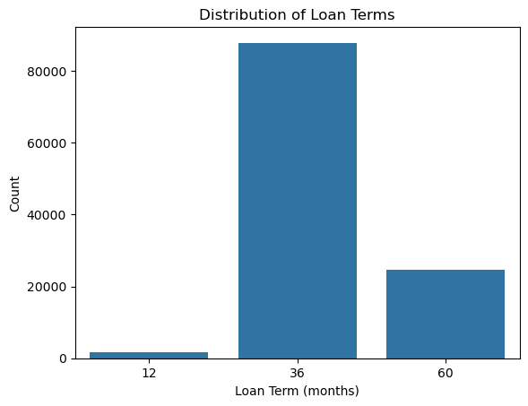

```python
plt.figure()
sns.countplot(data=df_cleaned, x='Term')
plt.title('Distribution of Loan Terms')
plt.xlabel('Loan Term (months)')
plt.ylabel('Count')
plt.show()
```

### Question 2: What is the distribution of loan statuses?

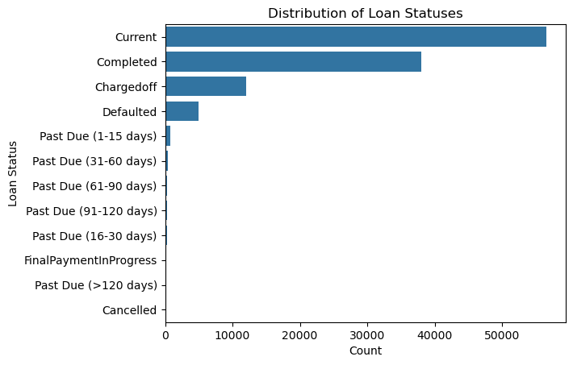

```python
plt.figure()
sns.countplot(data=df_cleaned, y='LoanStatus', order=df_cleaned['LoanStatus'].value_counts().index)
plt.title('Distribution of Loan Statuses')
plt.xlabel('Count')
plt.ylabel('Loan Status')
plt.show()
```

### Question 3: What is the distribution of income ranges among borrowers?

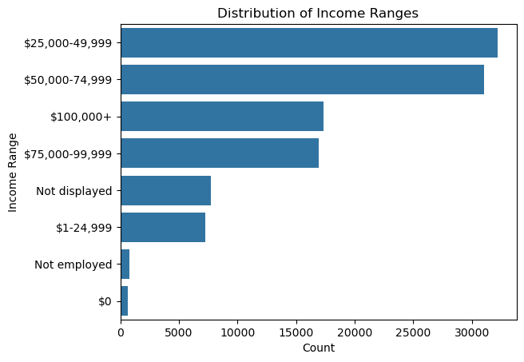

```python
plt.figure()
sns.countplot(data=df_cleaned, y='IncomeRange', order=df_cleaned['IncomeRange'].value_counts().index)
plt.title('Distribution of Income Ranges')
plt.xlabel('Count')
plt.ylabel('Income Range')
plt.show()
```

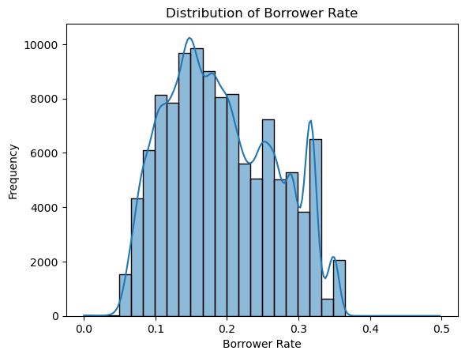

```python
plt.figure()
sns.histplot(df_cleaned['BorrowerRate'], bins=30, kde=True)
plt.title('Distribution of Borrower Rate')
plt.xlabel('Borrower Rate')
plt.ylabel('Frequency')
plt.show()
```

### Question 5: What is the distribution of Prosper Scores?

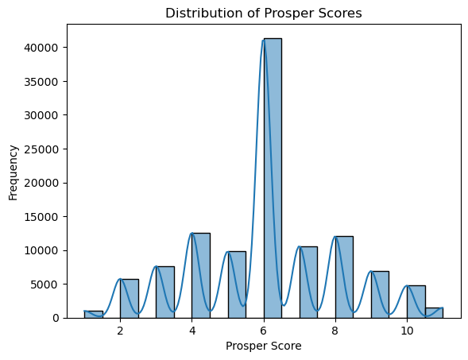

```python
plt.figure()
sns.histplot(df_cleaned['ProsperScore'], bins=20, kde=True)
plt.title('Distribution of Prosper Scores')
plt.xlabel('Prosper Score')
plt.ylabel('Frequency')
plt.show()
```

### Of the features you investigated, were there any unusual distributions? Did you perform any operations on the data to tidy, adjust, or change the form of the data? If so, why did you do this?

- Loan Statuses: The distribution was skewed towards 'Current' and 'Completed'.
- Borrower Rate: There were some outliers.

  No further transformations were made.

## Bivariate Exploration

### Question 1: How does the estimated return vary with Prosper Score?

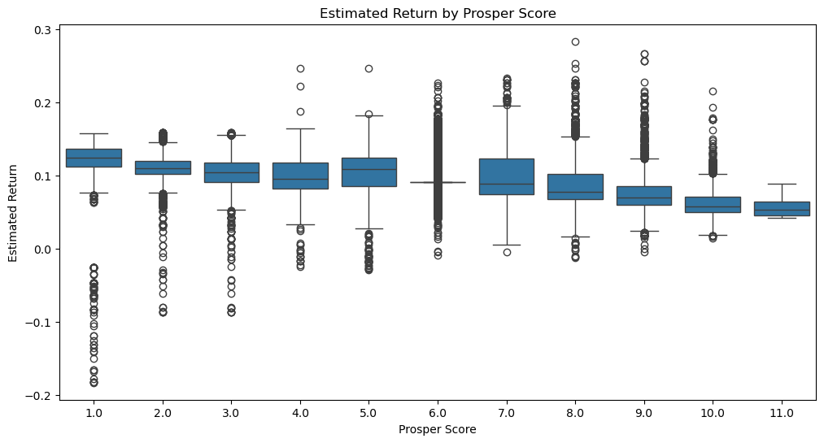

```python
plt.figure(figsize=(12, 6))
sns.boxplot(data=df_cleaned, x='ProsperScore', y='EstimatedReturn')
plt.title('Estimated Return by Prosper Score')
plt.xlabel('Prosper Score')
plt.ylabel('Estimated Return')
plt.show()
```

### Question 2: How does the debt-to-income ratio vary with loan status?

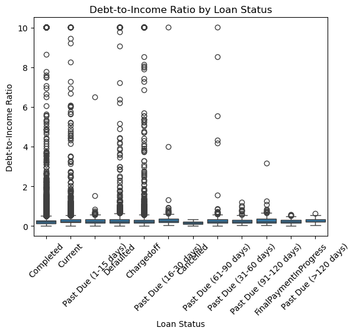

```python
plt.figure()
sns.boxplot(data=df_cleaned, x='LoanStatus', y='DebtToIncomeRatio')
plt.title('Debt-to-Income Ratio by Loan Status')
plt.xlabel('Loan Status')
plt.ylabel('Debt-to-Income Ratio')
plt.xticks(rotation=45)
plt.show()
```

### Question 3: How does borrower rate vary with lender yield?

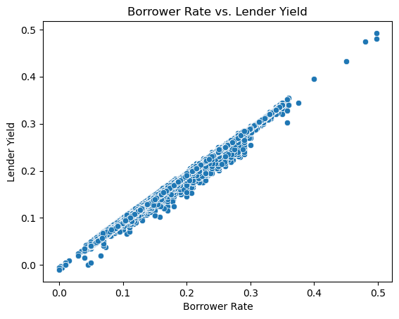

```python
plt.figure()
sns.scatterplot(data=df_cleaned, x='BorrowerRate', y='LenderYield')
plt.title('Borrower Rate vs. Lender Yield')
plt.xlabel('Borrower Rate')
plt.ylabel('Lender Yield')
plt.show()
```

### Question 4: Does income influence loan amount

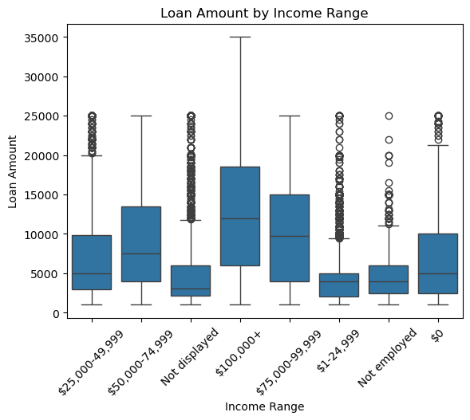

```python
plt.figure()
sns.boxplot(data=df, x='IncomeRange', y='LoanOriginalAmount')
plt.title('Loan Amount by Income Range')
plt.xlabel('Income Range')
plt.ylabel('Loan Amount')
plt.xticks(rotation=45)
plt.show()
```

### Question 5: How does employment status relate to loan status?

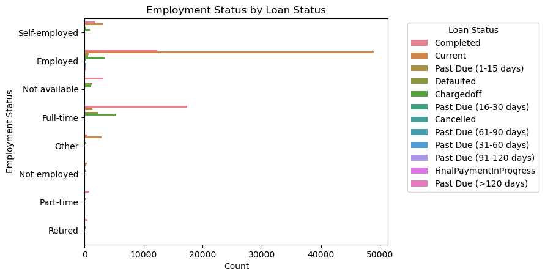

```python
plt.figure()
sns.countplot(data=df_cleaned, y='EmploymentStatus', hue='LoanStatus')
plt.title('Employment Status by Loan Status')
plt.xlabel('Count')
plt.ylabel('Employment Status')
plt.legend(title='Loan Status', bbox_to_anchor=(1.05, 1), loc='upper left')
plt.show()
```

## Conclusions

Using univariate and bivariate visualizations, the Prosper Loan dataset was examined in order to reveal several important insights on the behaviour of borrowers and impact on yield and returns.

Using the "Question-Visualization-Observations" structure, the dataset was methodically analyzed as part of the exploration process. This method made it possible to examine the data in an organized manner, which produced insightful findings. The dataset's distributions and relationships were clearly understood thanks to the visualizations, which also highlighted areas that would benefit from additional research or possible actions.

The procedure was recursive, enabling a thorough examination of the dataset with each visualization building upon the prior discoveries. A comprehensive analysis of individual traits and their interactions was ensured by the application of both univariate and bivariate methods.

All things considered, the investigation yielded insightful information on the Prosper Loan dataset, highlighting trends and connections that may guide choices or encourage more study.